# 1R y K vecinos más cercanos

Pablo Benavides-Herrera

2020-06-04

```r
library(easypackages)
packages("tidyverse", "readxl")
```

# Predicción de datos con **KNN**

```r
datos <- read_excel("Real estate valuation data set.xlsx")
datos
```

| No | X1 | X2 | X3 | X4 | X5 | X6 | Y |
| --- | --- | --- | --- | --- | --- | --- | --- |
| 1 | 2012.917 | 32.0 | 84.87882 | 10 | 24.98298 | 121.5402 | 37.9 |
| 2 | 2012.917 | 19.5 | 306.59470 | 9 | 24.98034 | 121.5395 | 42.2 |
| 3 | 2013.583 | 13.3 | 561.98450 | 5 | 24.98746 | 121.5439 | 47.3 |
| 4 | 2013.500 | 13.3 | 561.98450 | 5 | 24.98746 | 121.5439 | 54.8 |
| 5 | 2012.833 | 5.0 | 390.56840 | 5 | 24.97937 | 121.5425 | 43.1 |
| 6 | 2012.667 | 7.1 | 2175.03000 | 3 | 24.96305 | 121.5125 | 32.1 |
| 7 | 2012.667 | 34.5 | 623.47310 | 7 | 24.97933 | 121.5364 | 40.3 |
| 8 | 2013.417 | 20.3 | 287.60250 | 6 | 24.98042 | 121.5423 | 46.7 |
| 9 | 2013.500 | 31.7 | 5512.03800 | 1 | 24.95095 | 121.4846 | 18.8 |
| 10 | 2013.417 | 17.9 | 1783.18000 | 3 | 24.96731 | 121.5149 | 22.1 |

[output cut: 404 more lines]

La definición de las variables es la siguiente:

- X1: fecha de la transacción (por ejemplo 2013.250=2013 Marzo, * 2013.500=2013 Junio, etc.)
- X2: edad de la casa en años
- X3: distancial al MRT (transporte masivo) más cercano en metros
- X4: número de tiendas de conveniencia en el vecindario (entero)
- X5: latitud (unidad: grados)
- X6: longitude (unidad: grados)
- Y: precio por unidad de área (10000 Nuevos dólares taiwaneses/ 3.3 m2

Seleccionamos solo las variables edad de la casa, distancia al MRT, el número de tiendas de conveniencia y la variable de respuesta.

```r
datos_an <- datos %>%
  select(X2, X3, X4, Y)
datos_an
```

| X2 | X3 | X4 | Y |
| --- | --- | --- | --- |
| 32.0 | 84.87882 | 10 | 37.9 |
| 19.5 | 306.59470 | 9 | 42.2 |
| 13.3 | 561.98450 | 5 | 47.3 |
| 13.3 | 561.98450 | 5 | 54.8 |
| 5.0 | 390.56840 | 5 | 43.1 |
| 7.1 | 2175.03000 | 3 | 32.1 |
| 34.5 | 623.47310 | 7 | 40.3 |
| 20.3 | 287.60250 | 6 | 46.7 |
| 31.7 | 5512.03800 | 1 | 18.8 |
| 17.9 | 1783.18000 | 3 | 22.1 |

[output cut: 404 more lines]

## Estadística básica

```r
summary(datos_an)
```

```
       X2               X3                X4
 Min.   : 0.000   Min.   :  23.38   Min.   : 0.000
 1st Qu.: 9.025   1st Qu.: 289.32   1st Qu.: 1.000
 Median :16.100   Median : 492.23   Median : 4.000
 Mean   :17.713   Mean   :1083.89   Mean   : 4.094
 3rd Qu.:28.150   3rd Qu.:1454.28   3rd Qu.: 6.000
 Max.   :43.800   Max.   :6488.02   Max.   :10.000
       Y
 Min.   :  7.60
 1st Qu.: 27.70
 Median : 38.45
 Mean   : 37.98
 3rd Qu.: 46.60
 Max.   :117.50
```

```r
apply(datos_an,2,sd)
```

```
         X2          X3          X4           Y
  11.392485 1262.109595    2.945562   13.606488
```

## Objetivos

1. Predecir el precio por metro cuadrado de una vivienda en función de ciertas características (edad de la propiedad, la distancia al transporte y el número de comercios alrededor).

## Preguntas

- ¿Afecta la edad de la casa su valor?
- ¿En dónde se sitúan las casas con mejores características?
- ¿Se están pagando impuestos correctamente?

**¿Tenemos toda la información necesaria para resolver mi problema de predicción?**

*No. Probablemente no tenemos toda la información para hacer el mejor modelo. Informción como el número de baños y otras comodidades serían complementarias para hacer un buen modelo*

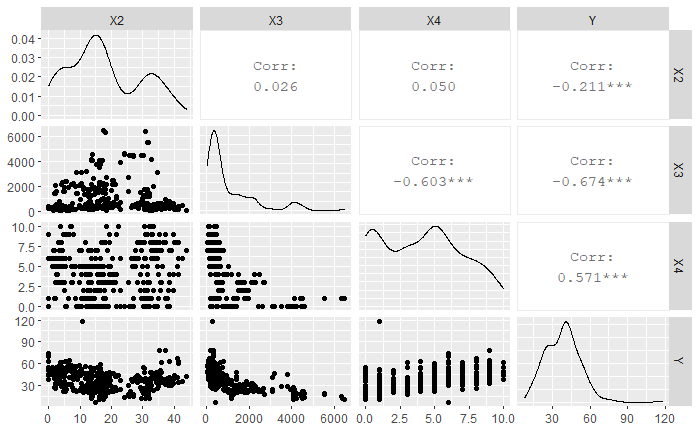

```r
datos_an %>%
  GGally::ggpairs()
```

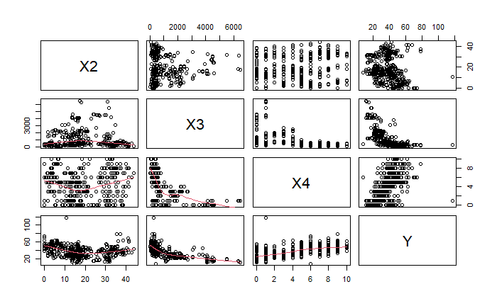

```r
pairs(datos_an, lower.panel = panel.smooth)
```

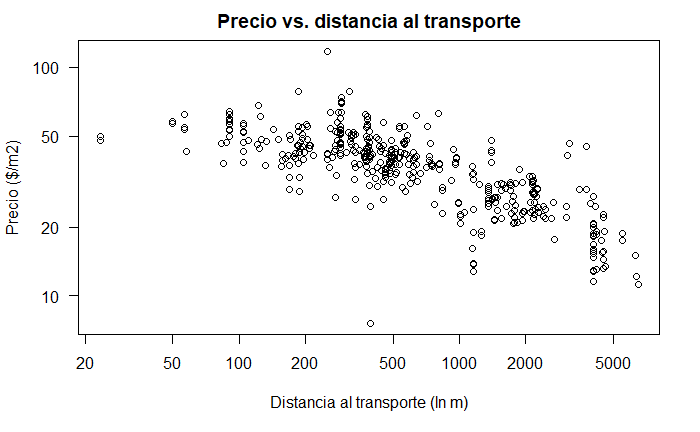

```r
plot(datos_an$X3, datos_an$Y, las=1, xlab = "Distancia al transporte (ln m)", ylab = "Precio ($/m2)", main = "Precio vs. distancia al transporte", log = "xy")
```

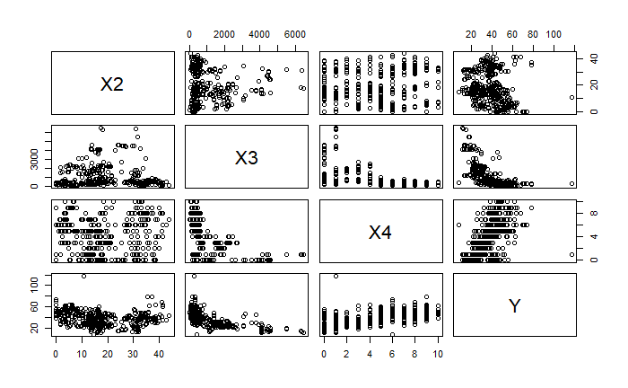

```r
plot(datos_an, )
```

```r
log_1 <- function(x,n = 1){
  log(x + n)
}
datos_an$X2log <- log(datos_an$X2+1)
datos_an$X3log <- log(datos_an$X3)
datos_an$X4log <- log(datos_an$X4+1)
datos_an$Ylog <- log(datos_an$Y)
# datos_an <- datos_an %>%
#   mutate_at(.vars = c("X2","X4"),.funs = log_1) %>%
#   mutate_at(.vars = c("X3","Y"), .funs = log)
datos_an
```

| X2 | X3 | X4 | Y | X2log | X3log | X4log | Ylog |
| --- | --- | --- | --- | --- | --- | --- | --- |
| 32.0 | 84.87882 | 10 | 37.9 | 3.4965076 | 4.441225 | 2.3978953 | 3.634951 |
| 19.5 | 306.59470 | 9 | 42.2 | 3.0204249 | 5.725527 | 2.3025851 | 3.742420 |
| 13.3 | 561.98450 | 5 | 47.3 | 2.6602595 | 6.331474 | 1.7917595 | 3.856510 |
| 13.3 | 561.98450 | 5 | 54.8 | 2.6602595 | 6.331474 | 1.7917595 | 4.003690 |
| 5.0 | 390.56840 | 5 | 43.1 | 1.7917595 | 5.967603 | 1.7917595 | 3.763523 |
| 7.1 | 2175.03000 | 3 | 32.1 | 2.0918641 | 7.684798 | 1.3862944 | 3.468856 |
| 34.5 | 623.47310 | 7 | 40.3 | 3.5695327 | 6.435306 | 2.0794415 | 3.696351 |
| 20.3 | 287.60250 | 6 | 46.7 | 3.0587071 | 5.661579 | 1.9459101 | 3.843744 |
| 31.7 | 5512.03800 | 1 | 18.8 | 3.4873751 | 8.614690 | 0.6931472 | 2.933857 |
| 17.9 | 1783.18000 | 3 | 22.1 | 2.9391619 | 7.486154 | 1.3862944 | 3.095578 |

[output cut: 404 more lines]

Escalamiento de las variables

```r
datos_an_scale <- scale(datos_an, center = TRUE, scale = TRUE)
medias <- attr(datos_an_scale, "scaled.center")
devsv_Est <- attr(datos_an_scale, "scaled.scale")
datos_an_scale <- as_tibble(datos_an_scale)
medias
```

[output not shown]

## Calibración de un modelo lineal

### Separación del conjunto de datos en entrenamiento y validación

```r
set.seed(20200604)
p_vl <- 0.2
N <- dim(datos_an_scale)[1]
ix_vl <- sample(N, round(p_vl*N), replace = FALSE)
datos_tr <- datos_an_scale[-ix_vl,]
datos_vl <- datos_an_scale[ix_vl,]
```

### Ajuste de un modelo lineal

```r
modelo_lm <- lm(Ylog ~ X2log + X3log + X4log, data = datos_tr)
summary(modelo_lm)
```

```
Call:
lm(formula = Ylog ~ X2log + X3log + X4log, data = datos_tr)

Residuals:
    Min      1Q  Median      3Q     Max
-4.2723 -0.3112  0.0124  0.3249  2.7786

Coefficients:
              Estimate Std. Error t value Pr(>|t|)
(Intercept) -0.0007627  0.0336466  -0.023    0.982
X2log       -0.1706887  0.0351169  -4.861 1.82e-06 ***
X3log       -0.5774408  0.0440867 -13.098  < 2e-16 ***
X4log        0.2194822  0.0438966   5.000 9.37e-07 ***
---
Signif. codes:  0 ‘***’ 0.001 ‘**’ 0.01 ‘*’ 0.05 ‘.’ 0.1 ‘ ’ 1

Residual standard error: 0.6117 on 327 degrees of freedom
Multiple R-squared:  0.634, Adjusted R-squared:  0.6306
F-statistic: 188.8 on 3 and 327 DF,  p-value: < 2.2e-16
```

Todos los modelos deben contener un intercepto, a menos que la variable *Y* haya sido centrada.

```r
modelo_lm <- lm(Ylog ~ -1 + X2log + X3log + X4log, data = datos_tr)
summary(modelo_lm)
```

```
Call:
lm(formula = Ylog ~ -1 + X2log + X3log + X4log, data = datos_tr)

Residuals:
    Min      1Q  Median      3Q     Max
-4.2731 -0.3120  0.0117  0.3241  2.7778

Coefficients:
      Estimate Std. Error t value Pr(>|t|)
X2log -0.17068    0.03506  -4.868 1.75e-06 ***
X3log -0.57744    0.04402 -13.118  < 2e-16 ***
X4log  0.21951    0.04381   5.010 8.91e-07 ***
---
Signif. codes:  0 ‘***’ 0.001 ‘**’ 0.01 ‘*’ 0.05 ‘.’ 0.1 ‘ ’ 1

Residual standard error: 0.6107 on 328 degrees of freedom
Multiple R-squared:  0.6342,    Adjusted R-squared:  0.6308
F-statistic: 189.5 on 3 and 328 DF,  p-value: < 2.2e-16
```

## Diagnóstico de residuos

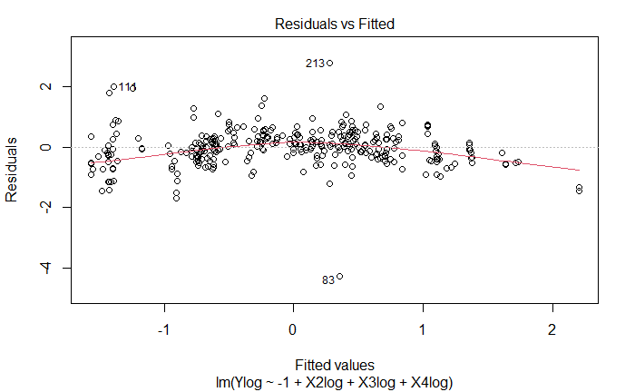

```r
plot(modelo_lm, which = 1)
```

Aquí se espera no ver patrones, ni observaciones *sospechosas*.c

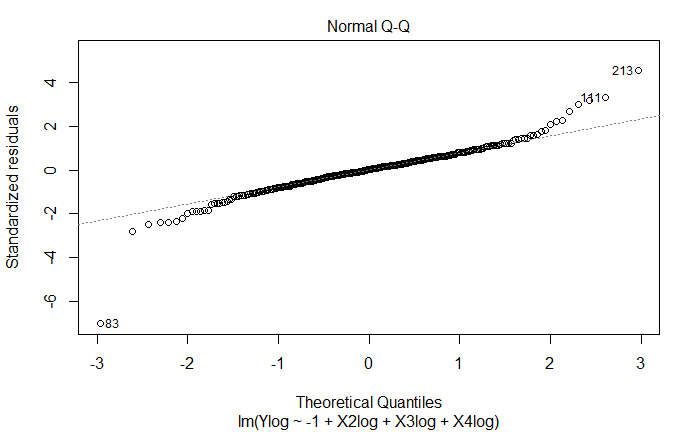

```r
plot(modelo_lm, which = 2)
```

Esperamos que siga la línea punteada. Si las colas se alejan, se comienza a perder el supuesto de normalidad en los residuos.

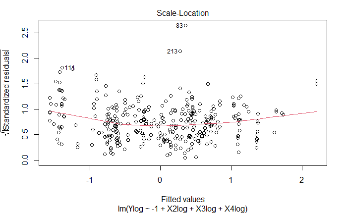

```r
plot(modelo_lm, which = 3)
```

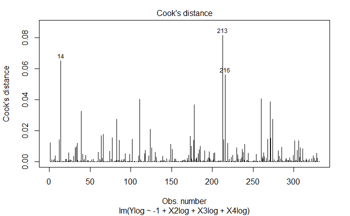

```r
plot(modelo_lm, which = 4)
```

La distancia de Cook nos permite ver qué tanto cambian los errores de un modelo, cuando se quitan ciertas observaciones.

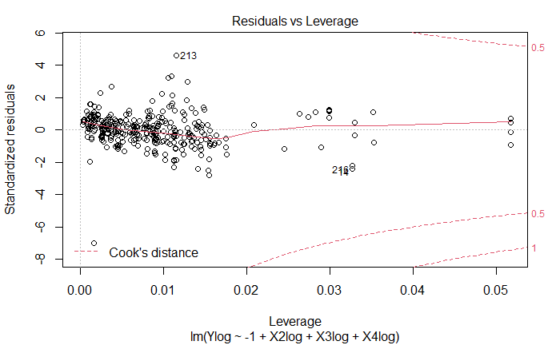

```r
plot(modelo_lm, which = 5)
```

El *leverage* es una métrica de qué tanto cambia una predicción, cuando cambia el valor real de esa observación.

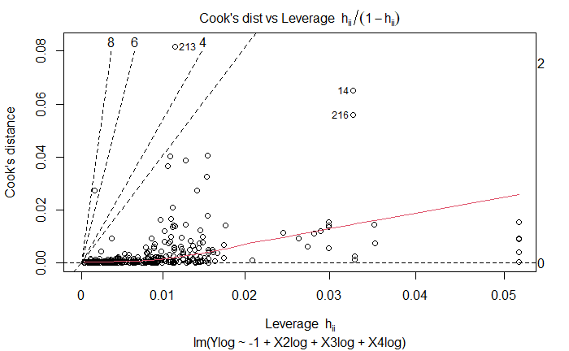

```r
plot(modelo_lm, which = 6)
```

La distancia de Cook vs. Leverage. Las observaciones que tienen grandes distancias de Cook y Leverage están afectando más fuertemente al modelo.

Ahora un modelo lineal con interacciones.

```r
modelo_lm_int <- lm(Ylog ~ -1 + X2log + X3log + X4log + X3log:X4log, data = datos_tr)
summary(modelo_lm_int)
```

```
Call:
lm(formula = Ylog ~ -1 + X2log + X3log + X4log + X3log:X4log,
    data = datos_tr)

Residuals:
    Min      1Q  Median      3Q     Max
-4.2335 -0.2464  0.0741  0.3523  2.7015

Coefficients:
            Estimate Std. Error t value Pr(>|t|)
X2log       -0.16383    0.03464  -4.729 3.36e-06 ***
X3log       -0.57305    0.04343 -13.195  < 2e-16 ***
X4log        0.19934    0.04366   4.566 7.06e-06 ***
X3log:X4log  0.08979    0.02800   3.206  0.00148 **
---
Signif. codes:  0 ‘***’ 0.001 ‘**’ 0.01 ‘*’ 0.05 ‘.’ 0.1 ‘ ’ 1

Residual standard error: 0.6023 on 327 degrees of freedom
Multiple R-squared:  0.6453,    Adjusted R-squared:  0.641
F-statistic: 148.7 on 4 and 327 DF,  p-value: < 2.2e-16
```

```r
anova(modelo_lm_int, modelo_lm)
```

```
Analysis of Variance Table

Model 1: Ylog ~ -1 + X2log + X3log + X4log + X3log:X4log
Model 2: Ylog ~ -1 + X2log + X3log + X4log
  Res.Df    RSS Df Sum of Sq     F   Pr(>F)
1    327 118.61
2    328 122.34 -1   -3.7287 10.28 0.001478 **
---
Signif. codes:  0 ‘***’ 0.001 ‘**’ 0.01 ‘*’ 0.05 ‘.’ 0.1 ‘ ’ 1
```

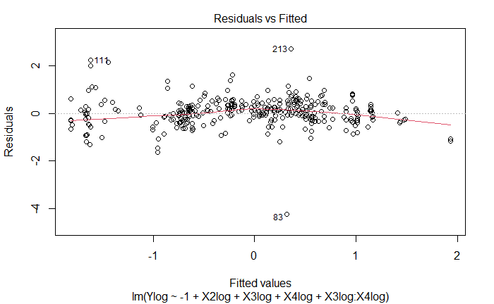

```r
plot(modelo_lm_int, which = 1)
```

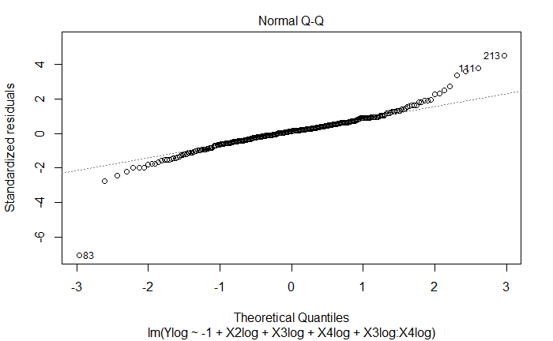

```r
plot(modelo_lm_int, which = 2)
```

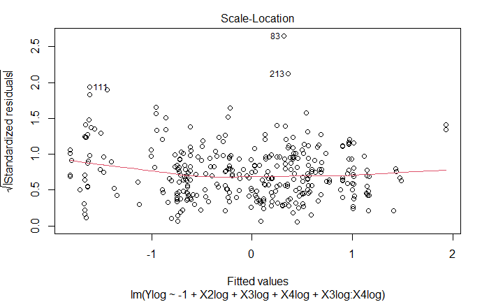

```r
plot(modelo_lm_int, which = 3)
```

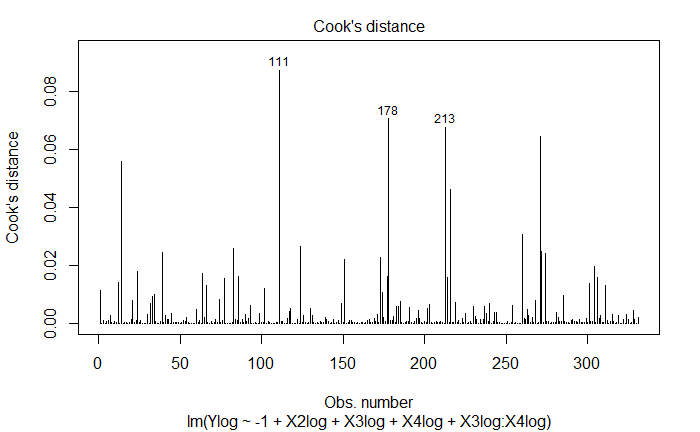

```r
plot(modelo_lm_int, which = 4)
```

Residuales estandarizados versus *leverage*:

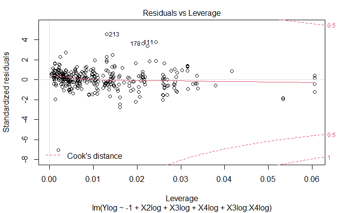

```r
plot(modelo_lm_int, which = 5)
```

La distancia de Cook vs. el *leverage*. Un leverage muy alto significa que la observación tiene un impacto muy fuerte sobre su propia predicción.

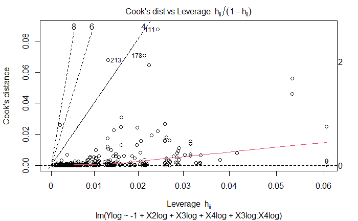

```r
plot(modelo_lm_int, which = 6)
```

```r
modelo2 <- lm(Ylog ~ -1 + X2log + X3log + X4log, data = datos_tr)
summary(modelo2)
```

```
Call:
lm(formula = Ylog ~ -1 + X2log + X3log + X4log, data = datos_tr)

Residuals:
    Min      1Q  Median      3Q     Max
-4.2731 -0.3120  0.0117  0.3241  2.7778

Coefficients:
      Estimate Std. Error t value Pr(>|t|)
X2log -0.17068    0.03506  -4.868 1.75e-06 ***
X3log -0.57744    0.04402 -13.118  < 2e-16 ***
X4log  0.21951    0.04381   5.010 8.91e-07 ***
---
Signif. codes:  0 ‘***’ 0.001 ‘**’ 0.01 ‘*’ 0.05 ‘.’ 0.1 ‘ ’ 1

Residual standard error: 0.6107 on 328 degrees of freedom
Multiple R-squared:  0.6342,    Adjusted R-squared:  0.6308
F-statistic: 189.5 on 3 and 328 DF,  p-value: < 2.2e-16
```